# Linear Algebra4 Statistical Genetics 2

Kensho Suzuki

## Exercise 1

### Exercise 1-1

*原点とは異なる点(p,q)が、Mによって不動であったと言う。行列Mの4成分について言えることは何か。*
行列Mを
$$M = \begin{pmatrix} a & b \\ c & d \end{pmatrix}\\$$
とすると、$\begin{pmatrix} p \\ q \end{pmatrix}$は固有ベクトルの一つとなる。
$$\begin{pmatrix} a & b \\ c & d \end{pmatrix} \begin{pmatrix} p \\ q \end{pmatrix} = \begin{pmatrix} p \\ q \end{pmatrix}\\
\Leftrightarrow \begin{cases} pa + qb =p \\ pc + qd =q \end{cases}\\
\begin{cases} b = \frac{p}{q}(1-a) \\ c = \frac{q}{p}(1-d) \end{cases}\\$$
を満たす。
また、固有値は$\begin{cases} 1 \\ a + d - 1 \end{cases}$ であり、
$det(M-E) = 0$となる。

### Exercise 1-2

*点(2,3)がMによって点(4,6)に移動したという。 点(4,6)はどこに移動するか。*
$$M \begin{pmatrix} 2 \\ 3 \end{pmatrix} = \begin{pmatrix} 4 \\ 6 \end{pmatrix} = 2 \begin{pmatrix} 2 \\ 3 \end{pmatrix} \\$$
なので、
$$M \begin{pmatrix} 4 \\ 6 \end{pmatrix} = 2M \begin{pmatrix} 2 \\ 3 \end{pmatrix}\\
= \begin{pmatrix} 8 \\ 12 \end{pmatrix}$$

### Exercise 1-3

*原点以外のすべての点が不動点でないようなMはどのようなMか。*  
固有値に1を持たない行列Mは、原点以外の不動点を持たない。

## Exercise 2

### Exercise 2-1

*固有値と固有ベクトルを指定し、それに対応する2×2変換行列を作成する関数を作れ*

```r
eigens.into_2by2matrix <- function(lambda1, lambda2, v1, v2){
  c1 <- (v1[1]/sqrt(v1[1]^2 + v1[2]^2))
  s1 <- (v1[2]/sqrt(v1[1]^2 + v1[2]^2))
  c2 <- (v2[1]/sqrt(v2[1]^2 + v2[2]^2))
  s2 <- (v2[2]/sqrt(v2[1]^2 + v2[2]^2))
  V <- matrix(c(c1,s1,c2,s2),2,2)
  s <- matrix(c(lambda1,0,0,lambda2),2,2)
  return(V %*% s %*% solve(V))
}

lambda1 = 4
lambda2 = 9
v1 = c(1,-4)
v2 = c(1,1)

M <- eigens.into_2by2matrix(lambda1, lambda2, v1, v2)
M
```

```
##      [,1] [,2]
## [1,]    8    1
## [2,]    4    5
```

```r
eigen(M)
```

```
## eigen() decomposition
## $values
## [1] 9 4
##
## $vectors
##           [,1]       [,2]
## [1,] 0.7071068 -0.2425356
## [2,] 0.7071068  0.9701425
```

### Exercise 2-2

*点(1,0)を点(1,2)に移し、点(0,1)を点(2,4)に移す行列を作り、その行列の固有値と固有ベクトルを計算すると以下のように固有値の一つは0となる。この行列によって、第一固有ベクトル方向の点が、その方向に5倍した点に移ることを計算して確かめよ。*

```r
M <- matrix(c(1,2,2,4),2,2)
x1 <- c(1,2)

M %*% x1
```

```
##      [,1]
## [1,]    5
## [2,]   10
```

```r
5 * x1
```

```
## [1]  5 10
```

### Exercise 2-3

*上記の行列によって、第一固有ベクトル方向以外の点がどこに移されるか計算して確かめよ。*

```r
x2 <- c(-1,3)

M %*% x2
```

```
##      [,1]
## [1,]    5
## [2,]   10
```

### Exercise 2-4

*この行列の逆行列をRで計算するとどうなるか実行せよ。*

```r
> solve(M)
 solve.default(M) でエラー:
  Lapack routine dgesv: システムは正確に特異です: U[2,2] = 0
```

*行列Mによって点vが点uに移せるとき、逆行列Mによって点uは点vに移るはずだが、この逆行列がうまく求まらない、ということと、行列Mの変換の特徴(Exercise 2-3)との関係を述べよ。*

あるベクトルを第一固有ベクトル成分と第二固有ベクトル成分に分解して考えると、  
行列Mは第二固有ベクトル成分を0にするため、全てのベクトルは第一固有ベクトルのみとなる。  
つまり、この行列Mは元のベクトルの情報を保持しなくなる変換と考えることができ、  
従ってその逆行列は存在し得ない。

### Exercise 2-5

$$M = \begin{pmatrix} 1 & 2 \\ 3 & 4 \end{pmatrix}\\$$
*の固有値を求めよ。*
$$det(M-\lambda E) = 0\\
\Leftrightarrow \lambda^2 - 5\lambda -2 = 0\\
\Leftrightarrow \begin{cases} \lambda_{1} = \frac{5 + \sqrt{33}}{2} = 5.372281 \\ \lambda_{2} = \frac{5 - \sqrt{33}}{2} = -0.3722813 \end{cases}\\$$

### Exercise 2-6

*$2\times 2$行列$\begin{pmatrix} a & b \\ c & d \end{pmatrix}$の固有値を行列の成分で表せ。*
$$det(M-\lambda E) = 0\\
\Leftrightarrow \lambda^2 - (a + d)\lambda +(ad - bc) = 0\\
\Leftrightarrow \lambda = \frac{(a+d) \pm \sqrt{(a+d)^2 - 4(ad - bc)}}{2}\\
= \frac{(a+d) \pm \sqrt{(a - d)^2 + 4bc}}{2}$$

### Exercise 2-7

```r
Mi <- matrix(c(1,-1,2,1),2,2)
eigen(M)
```

```
## eigen() decomposition
## $values
## [1] 5 0
##
## $vectors
##           [,1]       [,2]
## [1,] 0.4472136 -0.8944272
## [2,] 0.8944272  0.4472136
```

### Exercise 2-8

```r
my.matrix.power <- function(X,p){
    if(p == 0){
        one <- diag(1,dim(X)[1],dim(X)[2])
        return(one)
    } else{
        s <- eigen(X)[[1]]
        if(class(s) == "numeric"){
          s <- complex(real=eigen(X)[[1]],imaginary=0)
        }
        V <- eigen(X)[[2]]
        X <- V %*% diag(s^(p)) %*% solve(V)
        return(X)
    }
}

t_list <- c(0:5)
X <- matrix(c(1,1),2,1)
Y <- matrix(0,length(t_list),2)
Yi <- matrix(0,length(t_list),2)

M
```

```
##      [,1] [,2]
## [1,]    1    2
## [2,]    2    4
```

```r
eigen(M)
```

```
## eigen() decomposition
## $values
## [1] 5 0
##
## $vectors
##           [,1]       [,2]
## [1,] 0.4472136 -0.8944272
## [2,] 0.8944272  0.4472136
```

```r
for (t in t_list) {
  Y[t+1,] <- t(my.matrix.power(M,t) %*% X)
}
Y
```

```
##         [,1]    [,2]
## [1,]    1+0i    1+0i
## [2,]    3+0i    6+0i
## [3,]   15+0i   30+0i
## [4,]   75+0i  150+0i
## [5,]  375+0i  750+0i
## [6,] 1875+0i 3750+0i
```

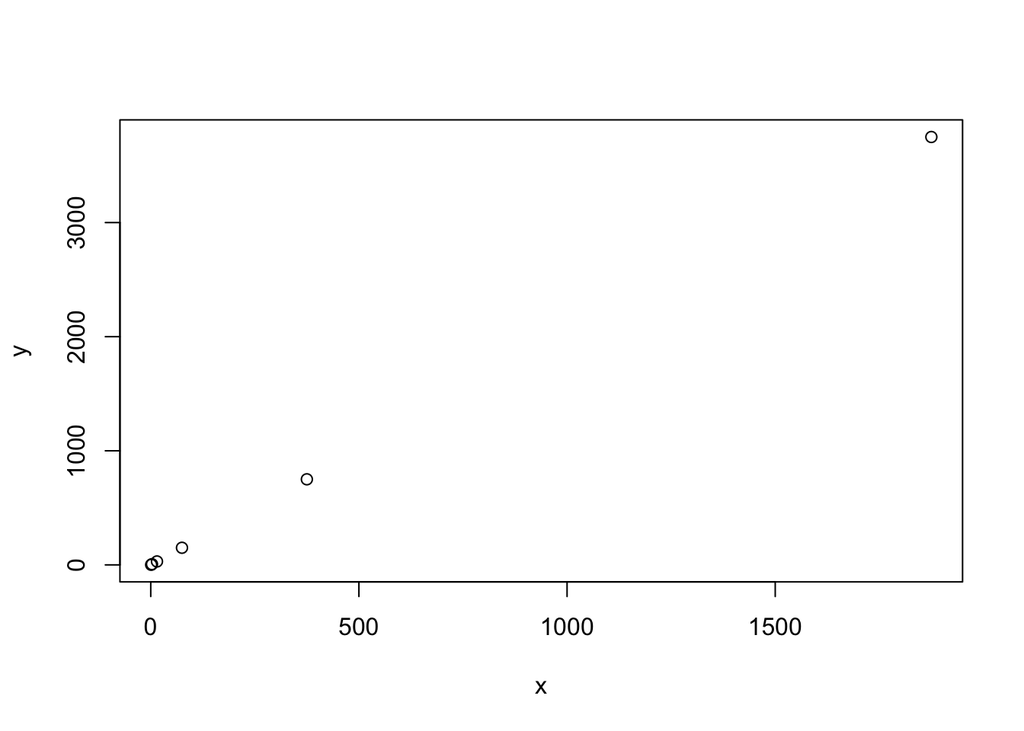

```r
plot(Re(Y[,1]),Re(Y[,2]),xlab="x",ylab="y")
```

```r
Mi
```

```
##      [,1] [,2]
## [1,]    1    2
## [2,]   -1    1
```

```r
eigen(Mi)
```

```
## eigen() decomposition
## $values
## [1] 1+1.414214i 1-1.414214i
##
## $vectors
##                      [,1]                 [,2]
## [1,] 0.8164966+0.0000000i 0.8164966+0.0000000i
## [2,] 0.0000000+0.5773503i 0.0000000-0.5773503i
```

```r
for (t in t_list) {
  Yi[t+1,] <- t(my.matrix.power(Mi,t) %*% X)
}
Yi
```

```
##        [,1]  [,2]
## [1,]   1+0i  1+0i
## [2,]   3+0i  0+0i
## [3,]   3+0i -3+0i
## [4,]  -3+0i -6+0i
## [5,] -15+0i -3+0i
## [6,] -21+0i 12+0i
```

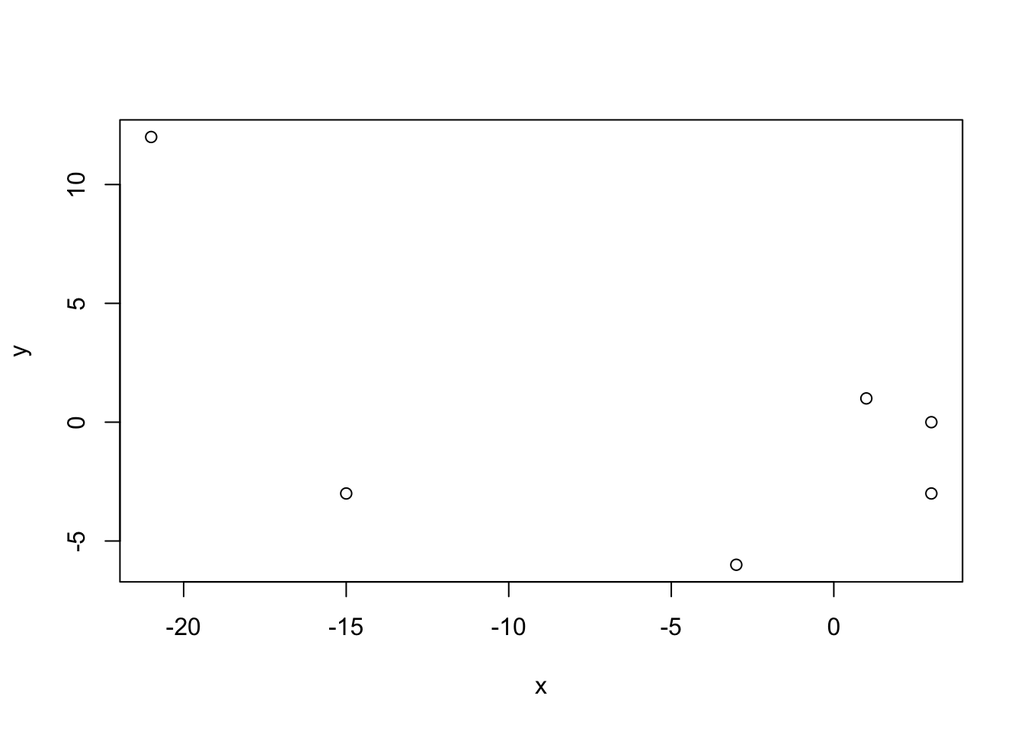

```r
plot(Re(Yi[,1]),Re(Yi[,2]),xlab="x",ylab="y")
```

## Exercise 3

### Exercise 3-1

点(1,2)を動かさず、点(2,2)を点(3,5)に移し、点(1,3)を点(4,6)に移すAffine 変換は、  
(2,2)-(1,2) = (1,0), (1,3)-(1,2)=(0,1)、 (3,5)-(2,1) = (1,4), (4,6)-(1,3)=(3,3)、  
であるから、(1,0)を(1,4)に移し、(0,1)を(3,3)に移す2×2行列 Mと、平行移動(0,0)->(1,2)との合成のはずである。  
行列Mを作成せよ。

条件より
$$\begin{cases} {M \begin{pmatrix} 2 \\ 2 \end{pmatrix} = \begin{pmatrix} 3 \\ 5 \end{pmatrix} - \begin{pmatrix} 1 \\ 2 \end{pmatrix} = \begin{pmatrix} 2 \\ 3 \end{pmatrix}} \\ {M \begin{pmatrix} 1 \\ 3 \end{pmatrix} = \begin{pmatrix} 4 \\ 6 \end{pmatrix} - \begin{pmatrix} 1 \\ 2 \end{pmatrix} = \begin{pmatrix} 3 \\ 4 \end{pmatrix}} \end{cases}$$
なので、
$$M \begin{pmatrix} 2 & 1 \\ 2 & 3 \end{pmatrix} = \begin{pmatrix} 2 & 3 \\ 3 & 4 \end{pmatrix}\\$$
従って
$$M = \frac{1}{4} \begin{pmatrix} 2 & 3 \\ 3 & 4 \end{pmatrix} \begin{pmatrix} 3 & -1 \\ -2 & 2 \end{pmatrix} = \begin{pmatrix} 0 & 1 \\ \frac{1}{4} & \frac{5}{4} \end{pmatrix}$$

*また、Affine 変換を表す3×3行列を作成せよ。*
$$\begin{pmatrix} y_1 \\ y_2 \\ 1 \end{pmatrix} = \begin{pmatrix} 0 & 1 & 1 \\ \frac{1}{4} & \frac{5}{4} & 2 \\ 0 & 0 & 1 \end{pmatrix} \begin{pmatrix} x_1 \\ x_2 \\ 1 \end{pmatrix}$$

*作成した3×3行列により、(1,2)が動かないことを確認せよ。*

```r
Af <- matrix(c(0,1/4,0,1,5/4,0,1,2,1),3,3)
Af
```

```
##      [,1] [,2] [,3]
## [1,] 0.00 1.00    1
## [2,] 0.25 1.25    2
## [3,] 0.00 0.00    1
```

```r
Af %*% c(2,2,1)
```

```
##      [,1]
## [1,]    3
## [2,]    5
## [3,]    1
```

```r
Af %*% c(1,3,1)
```

```
##      [,1]
## [1,]    4
## [2,]    6
## [3,]    1
```

```r
Af %*% c(0,0,1)
```

```
##      [,1]
## [1,]    1
## [2,]    2
## [3,]    1
```

```r
Af %*% c(1,2,1)
```

```
##      [,1]
## [1,] 3.00
## [2,] 4.75
## [3,] 1.00
```

このアフィン変換を行うと、点(1,2)自体は移動しているが、原点(0,0)は点(1,2)に移動するため、  
見かけ上、点(1,2)は不動点のようになる。